# Barcode Sharing Troubleshooting

## Presence of barcode in rescue virus stock

Plot frequency of each barcode and whether it is found in `wt` rescued virus stock, `syn` rescued virus stock, `both`, or `neither`.

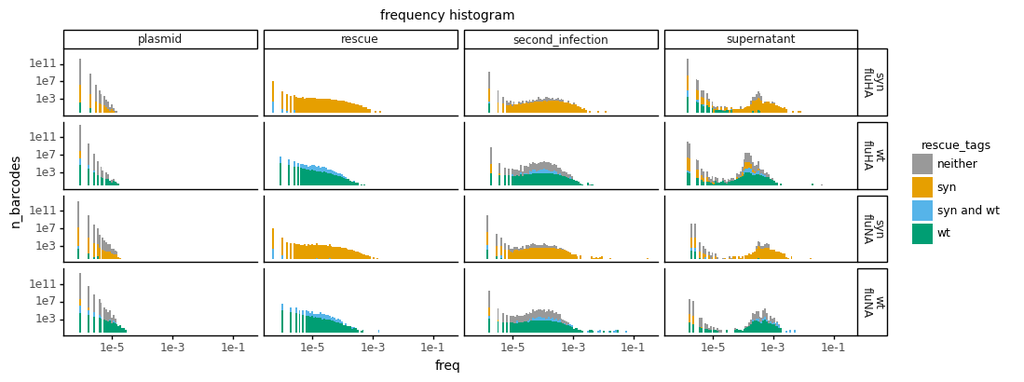

```python
fig = (p9.ggplot(viral_bc, p9.aes(x='freq', fill='rescue_tags')) +
       p9.geom_histogram(bins=100) +
       p9.facet_grid('gene+tag~source') +
       p9.ggtitle('frequency histogram') +
       p9.ylab('n_barcodes') +
       p9.scale_y_log10() +
       p9.scale_x_log10() +
       p9.theme(figure_size=(2.75*viral_bc['source'].nunique(),
                             2*viral_bc['gene'].nunique()),
                plot_title=p9.element_text(size=10),
                axis_title=p9.element_text(size=10),
                legend_title=p9.element_text(size=9),
                legend_title_align='center') +
       p9.scale_fill_manual(CBPALETTE[0:]))
fig
```

### Barcode sharing

Plot barcode sharing across tags from the same source (e.g. supernatant, second infection, etc...):

```python
shared_tags = (viral_bc
               .groupby(['source',
                         'gene',
                         'barcode',
                         'replicate'])
               .agg({'tag': lambda x: ' and '.join(sorted(set(x))),
                     'freq': lambda x: sum(x)})
               .reset_index())

display(shared_tags)
```

|  | source | gene | barcode | replicate | tag | freq |
| --- | --- | --- | --- | --- | --- | --- |
| 0 | plasmid | fluHA | AAAAAAAAAACCCCCA | replicate_1 | syn | 8.994974e-07 |
| 1 | plasmid | fluHA | AAAAAAAAAACCCGGA | replicate_1 | syn | 8.994974e-07 |
| 2 | plasmid | fluHA | AAAAAAAAAACGATAT | replicate_1 | wt | 8.647205e-07 |
| 3 | plasmid | fluHA | AAAAAAAAAATCACCG | replicate_1 | syn | 1.798995e-06 |
| 4 | plasmid | fluHA | AAAAAAAAAATGACGC | replicate_1 | syn | 8.994974e-07 |
| ... | ... | ... | ... | ... | ... | ... |
| 4982742 | supernatant | fluNA | TTTTTGGAATACGCAA | replicate_1 | wt | 2.453031e-04 |
| 4982743 | supernatant | fluNA | TTTTTGGGTTATTTTG | replicate_1 | syn | 1.008797e-05 |
| 4982744 | supernatant | fluNA | TTTTTTCTTTACAAGC | replicate_1 | wt | 1.764770e-06 |
| 4982745 | supernatant | fluNA | TTTTTTTCTAATTGTG | replicate_1 | syn | 2.521992e-06 |
| 4982746 | supernatant | fluNA | TTTTTTTGAAATGTTT | replicate_2 | syn | 1.978987e-06 |

4982747 rows × 6 columns

```python
frac_shared_tags = (shared_tags
                    .groupby(['source',
                              'gene',
                              'tag',
                              'replicate'])
                    .count()
                    .drop('freq', axis=1)
                    .reset_index())

frac_shared_tags = pd.merge(frac_shared_tags,
                            (frac_shared_tags
                             .groupby(['source',
                                       'gene',
                                       'replicate'])
                             .sum()
                             .reset_index()
                             .rename(columns={'barcode': 'count_total'})),
                            on=['source','gene', 'replicate'])

frac_shared_tags['frac_barcodes'] = (frac_shared_tags['barcode'] /
                                     frac_shared_tags['count_total'])

display(frac_shared_tags)
```

|  | source | gene | tag | replicate | barcode | count_total | frac_barcodes |
| --- | --- | --- | --- | --- | --- | --- | --- |
| 0 | plasmid | fluHA | syn | replicate_1 | 1026355 | 2064168 | 0.497225 |
| 1 | plasmid | fluHA | syn and wt | replicate_1 | 460 | 2064168 | 0.000223 |
| 2 | plasmid | fluHA | wt | replicate_1 | 1037353 | 2064168 | 0.502553 |
| 3 | plasmid | fluNA | syn | replicate_1 | 1080495 | 2030407 | 0.532157 |
| 4 | plasmid | fluNA | syn and wt | replicate_1 | 593 | 2030407 | 0.000292 |
| 5 | plasmid | fluNA | wt | replicate_1 | 949319 | 2030407 | 0.467551 |
| 6 | rescue | fluHA | syn | replicate_1 | 109891 | 413829 | 0.265547 |
| 7 | rescue | fluHA | syn and wt | replicate_1 | 299 | 413829 | 0.000723 |
| 8 | rescue | fluHA | wt | replicate_1 | 303639 | 413829 | 0.733731 |
| 9 | rescue | fluNA | syn | replicate_1 | 108374 | 343147 | 0.315824 |
| 10 | rescue | fluNA | syn and wt | replicate_1 | 284 | 343147 | 0.000828 |
| 11 | rescue | fluNA | wt | replicate_1 | 234489 | 343147 | 0.683349 |
| 12 | second_infection | fluHA | syn | replicate_1 | 8713 | 20494 | 0.425149 |
| 13 | second_infection | fluHA | syn and wt | replicate_1 | 74 | 20494 | 0.003611 |
| 14 | second_infection | fluHA | wt | replicate_1 | 11707 | 20494 | 0.571240 |
| 15 | second_infection | fluHA | syn | replicate_2 | 8399 | 20124 | 0.417362 |
| 16 | second_infection | fluHA | syn and wt | replicate_2 | 48 | 20124 | 0.002385 |
| 17 | second_infection | fluHA | wt | replicate_2 | 11677 | 20124 | 0.580252 |
| 18 | second_infection | fluNA | syn | replicate_1 | 8200 | 18974 | 0.432170 |
| 19 | second_infection | fluNA | syn and wt | replicate_1 | 118 | 18974 | 0.006219 |
| 20 | second_infection | fluNA | wt | replicate_1 | 10656 | 18974 | 0.561611 |
| 21 | second_infection | fluNA | syn | replicate_2 | 7920 | 18363 | 0.431302 |
| 22 | second_infection | fluNA | syn and wt | replicate_2 | 81 | 18363 | 0.004411 |
| 23 | second_infection | fluNA | wt | replicate_2 | 10362 | 18363 | 0.564287 |
| 24 | supernatant | fluHA | syn | replicate_1 | 7941 | 17864 | 0.444525 |
| 25 | supernatant | fluHA | syn and wt | replicate_1 | 853 | 17864 | 0.047750 |
| 26 | supernatant | fluHA | wt | replicate_1 | 9070 | 17864 | 0.507725 |
| 27 | supernatant | fluHA | syn | replicate_2 | 8412 | 17681 | 0.475765 |
| 28 | supernatant | fluHA | syn and wt | replicate_2 | 848 | 17681 | 0.047961 |
| 29 | supernatant | fluHA | wt | replicate_2 | 8421 | 17681 | 0.476274 |
| 30 | supernatant | fluNA | syn | replicate_1 | 3795 | 9021 | 0.420685 |
| 31 | supernatant | fluNA | syn and wt | replicate_1 | 74 | 9021 | 0.008203 |
| 32 | supernatant | fluNA | wt | replicate_1 | 5152 | 9021 | 0.571112 |
| 33 | supernatant | fluNA | syn | replicate_2 | 4238 | 8675 | 0.488530 |
| 34 | supernatant | fluNA | syn and wt | replicate_2 | 78 | 8675 | 0.008991 |
| 35 | supernatant | fluNA | wt | replicate_2 | 4359 | 8675 | 0.502478 |

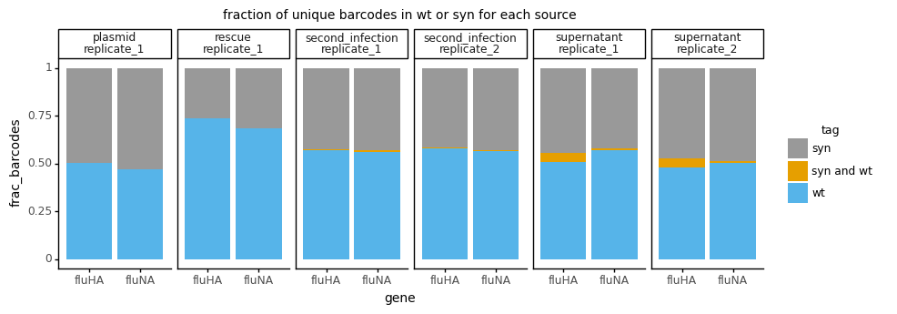

```python
fig = (p9.ggplot(frac_shared_tags,
                 p9.aes(x='gene',
                        y='frac_barcodes',
                        fill='tag')) +
       p9.geom_bar(stat='identity') +
       p9.ggtitle('fraction of unique barcodes in wt or syn for each source') +
       p9.facet_grid('~source+replicate') +
       p9.theme(figure_size=(2.5*frac_shared_tags['source'].nunique(), 3),
                plot_title=p9.element_text(size=10),
                axis_title=p9.element_text(size=10),
                legend_title=p9.element_text(size=9),
                legend_title_align='center') +
       p9.scale_fill_manual(CBPALETTE[0:]))

# show plot
fig
```

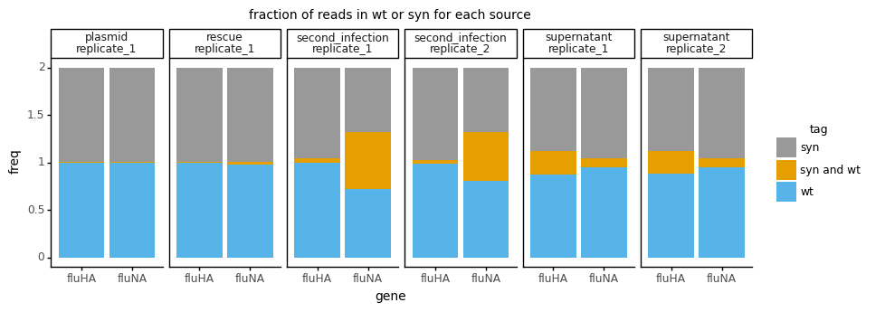

```python
fig = (p9.ggplot(shared_tags,
                 p9.aes(x='gene',
                        y='freq',
                        fill='tag')) +
       p9.geom_bar(stat='identity') +
       p9.ggtitle('fraction of reads in wt or syn for each source') +
       p9.facet_grid('~source+replicate') +
       p9.theme(figure_size=(2.5*shared_tags['source'].nunique(), 3),
                plot_title=p9.element_text(size=10),
                axis_title=p9.element_text(size=10),
                legend_title=p9.element_text(size=9),
                legend_title_align='center') +
       p9.scale_fill_manual(CBPALETTE[0:]))

# show plot
fig
```

Plot barcode frequency by sharing:

|  | source | tag | gene | replicate | barcode | count_barcode | count_total | freq | rescue_tags | tags_present |
| --- | --- | --- | --- | --- | --- | --- | --- | --- | --- | --- |
| 0 | plasmid | syn | fluHA | replicate_1 | ATTGTAATTTTTTATT | 15 | 1111732 | 0.000013 | neither | syn |
| 1 | plasmid | syn | fluHA | replicate_1 | GAGTAAAATTCCTACT | 15 | 1111732 | 0.000013 | neither | syn |
| 2 | plasmid | syn | fluHA | replicate_1 | ACAGCATAGAAAACGC | 14 | 1111732 | 0.000013 | neither | syn |
| 3 | plasmid | syn | fluHA | replicate_1 | TACCACAAAAAAATAA | 14 | 1111732 | 0.000013 | neither | syn |
| 4 | plasmid | syn | fluHA | replicate_1 | AATAATGAACAATGAC | 13 | 1111732 | 0.000012 | syn | syn |
| ... | ... | ... | ... | ... | ... | ... | ... | ... | ... | ... |
| 4986552 | supernatant | wt | fluNA | replicate_2 | TTTTATTTATTGACGG | 1 | 460743 | 0.000002 | neither | wt |
| 4986553 | supernatant | wt | fluNA | replicate_2 | TTTTCAGATTTACGCA | 1 | 460743 | 0.000002 | neither | wt |
| 4986554 | supernatant | wt | fluNA | replicate_2 | TTTTCGGGTTATTTTG | 1 | 460743 | 0.000002 | syn | wt |
| 4986555 | supernatant | wt | fluNA | replicate_2 | TTTTGATGGTAAGTTC | 1 | 460743 | 0.000002 | neither | wt |
| 4986556 | supernatant | wt | fluNA | replicate_2 | TTTTGTAATAATGCAG | 1 | 460743 | 0.000002 | neither | wt |

4986557 rows × 10 columns

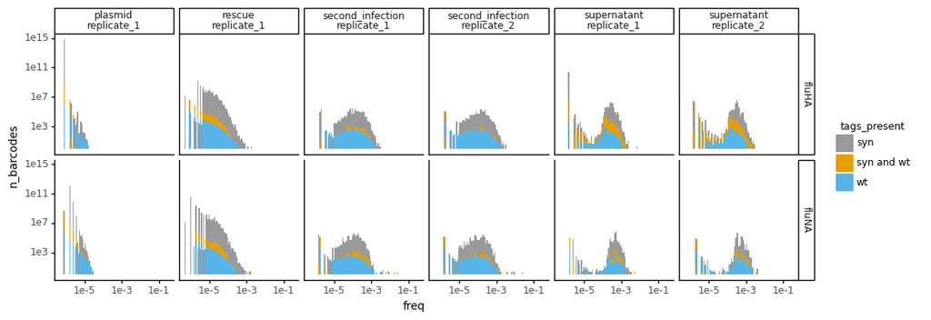

```python
viral_bc = pd.merge(viral_bc,
                    shared_tags.drop('freq', axis=1),
                    on=['source', 'gene', 'barcode', 'replicate'],
                    suffixes=[None, 's_present'])

display(viral_bc)

fig = (p9.ggplot(viral_bc, p9.aes(x='freq', fill='tags_present')) +
       p9.geom_histogram(bins=100) +
       p9.facet_grid('gene~source+replicate') +
       p9.scale_y_log10() +
       p9.scale_x_log10() +
       p9.theme(figure_size=(3*viral_bc['source'].nunique(),
                             2*viral_bc['gene'].nunique()),
                plot_title=p9.element_text(size=10),
                axis_title=p9.element_text(size=10),
                legend_title=p9.element_text(size=9),
                legend_title_align='center') +
       p9.ylab('n_barcodes') +
       p9.scale_fill_manual(CBPALETTE[0:]))
fig
```

Plot frequencies of barcodes and color by which tag (or both) they are found in:

| tag | source | gene | barcode | tags_present | replicate | syn | wt |
| --- | --- | --- | --- | --- | --- | --- | --- |
| 0 | plasmid | fluHA | AAAAAAAAAACCCCCA | syn | replicate_1 | 8.994974e-07 | 0.000000e+00 |
| 1 | plasmid | fluHA | AAAAAAAAAACCCGGA | syn | replicate_1 | 8.994974e-07 | 0.000000e+00 |
| 2 | plasmid | fluHA | AAAAAAAAAACGATAT | wt | replicate_1 | 0.000000e+00 | 8.647205e-07 |
| 3 | plasmid | fluHA | AAAAAAAAAATCACCG | syn | replicate_1 | 1.798995e-06 | 0.000000e+00 |
| 4 | plasmid | fluHA | AAAAAAAAAATGACGC | syn | replicate_1 | 8.994974e-07 | 0.000000e+00 |
| ... | ... | ... | ... | ... | ... | ... | ... |
| 4982742 | supernatant | fluNA | TTTTTGGAATACGCAA | wt | replicate_1 | 0.000000e+00 | 2.453031e-04 |
| 4982743 | supernatant | fluNA | TTTTTGGGTTATTTTG | syn | replicate_1 | 1.008797e-05 | 0.000000e+00 |
| 4982744 | supernatant | fluNA | TTTTTTCTTTACAAGC | wt | replicate_1 | 0.000000e+00 | 1.764770e-06 |
| 4982745 | supernatant | fluNA | TTTTTTTCTAATTGTG | syn | replicate_1 | 2.521992e-06 | 0.000000e+00 |
| 4982746 | supernatant | fluNA | TTTTTTTGAAATGTTT | syn | replicate_2 | 1.978987e-06 | 0.000000e+00 |

4982747 rows × 7 columns

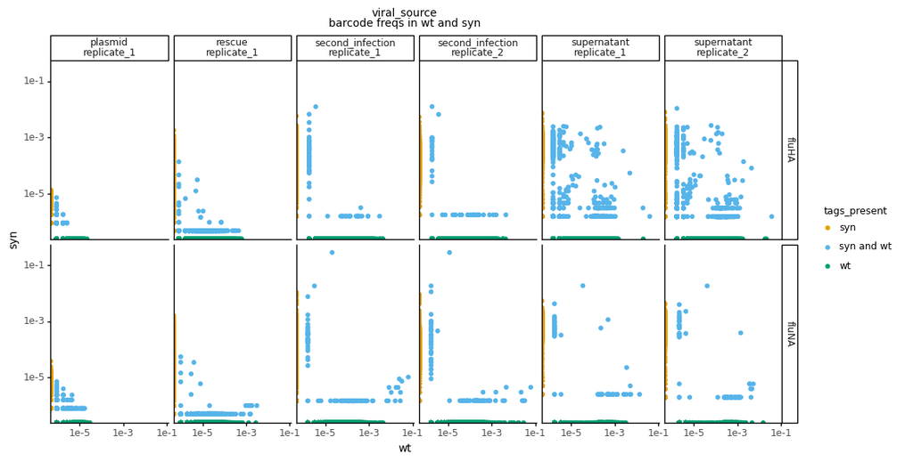

```python
tag_freqs = (viral_bc
             .pivot_table(index=['source',
                                 'gene',
                                 'barcode',
                                 'tags_present',
                                 'replicate'],
                          columns=['tag'],
                          values='freq')
             .fillna(0)
             .reset_index())

display(tag_freqs)

fig = (p9.ggplot(tag_freqs,
                 p9.aes(x='wt',
                        y='syn',
                        color='tags_present')) +
       p9.ggtitle(f'{expt}\n'
                  'barcode freqs in wt and syn') +
       p9.geom_point() +
       p9.facet_grid('gene~source+replicate') +
       p9.theme(figure_size=(12, 6),
                plot_title=p9.element_text(size=10),
                axis_title=p9.element_text(size=10),
                legend_title=p9.element_text(size=9),
                legend_title_align='center') +
       p9.scale_x_log10() +
       p9.scale_y_log10() +
       p9.scale_color_manual(CBPALETTE[1:]))
fig
```

Plot how often each barcode is found in the rescued virus data:

|  | source | gene | tag | replicate | tags_present | rescue_tags | count_barcode_group | count_barcode_total | frac |
| --- | --- | --- | --- | --- | --- | --- | --- | --- | --- |
| 0 | plasmid | fluHA | syn | replicate_1 | syn | neither | 1015011 | 1026815 | 9.885043e-01 |
| 1 | plasmid | fluHA | syn | replicate_1 | syn | syn | 11202 | 1026815 | 1.090946e-02 |
| 2 | plasmid | fluHA | syn | replicate_1 | syn | syn and wt | 1 | 1026815 | 9.738853e-07 |
| 3 | plasmid | fluHA | syn | replicate_1 | syn | wt | 141 | 1026815 | 1.373178e-04 |
| 4 | plasmid | fluHA | syn | replicate_1 | syn and wt | neither | 423 | 1026815 | 4.119535e-04 |
| ... | ... | ... | ... | ... | ... | ... | ... | ... | ... |
| 154 | supernatant | fluNA | wt | replicate_2 | syn and wt | wt | 36 | 4437 | 8.113590e-03 |
| 155 | supernatant | fluNA | wt | replicate_2 | wt | neither | 2536 | 4437 | 5.715574e-01 |
| 156 | supernatant | fluNA | wt | replicate_2 | wt | syn | 39 | 4437 | 8.789723e-03 |
| 157 | supernatant | fluNA | wt | replicate_2 | wt | syn and wt | 22 | 4437 | 4.958305e-03 |
| 158 | supernatant | fluNA | wt | replicate_2 | wt | wt | 1762 | 4437 | 3.971152e-01 |

159 rows × 9 columns

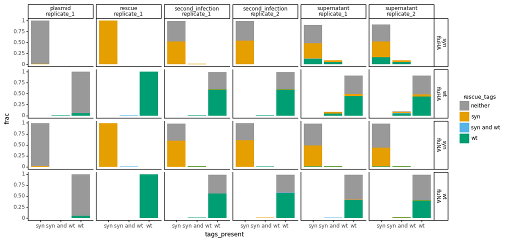

```python
temp_df = (viral_bc
           .groupby(['source',
                     'gene',
                     'tag',
                     'replicate',
                     'tags_present',
                     'rescue_tags'])
             .count()
             .reset_index()
            )


temp_df = temp_df[['source',
                   'gene',
                   'tag',
                   'replicate',
                   'tags_present',
                   'rescue_tags',
                   'count_barcode']]

temp_df = pd.merge(temp_df,
                    (temp_df
                     .groupby(['source',
                               'tag',
                               'gene',
                               'replicate'])
                     .sum()
                     .reset_index()),
                    on=['source', 'tag', 'gene', 'replicate'],
                    suffixes=('_group', '_total'))

temp_df['frac'] = (temp_df['count_barcode_group'] /
                   temp_df['count_barcode_total'])

display(temp_df)

fig = (p9.ggplot(temp_df,
                p9.aes(x='tags_present',
                       y='frac',
                       fill='rescue_tags')) +
       p9.geom_bar(stat='identity') +
       p9.facet_grid('gene+tag~source+replicate') +
       p9.theme(figure_size=(12,6),
                plot_title=p9.element_text(size=10),
                axis_title=p9.element_text(size=10),
                legend_title=p9.element_text(size=9),
                legend_title_align='center') +
       p9.scale_fill_manual(CBPALETTE[0:])
      )

fig
```

### Source frequency plots

Plot correlation for barcode frequencies in plasmid and rescue:

| source | gene | tag | barcode | tags_present | plasmid | rescue | second_infection | supernatant |
| --- | --- | --- | --- | --- | --- | --- | --- | --- |
| 0 | fluHA | syn | AAAAAAAAAACCCCCA | syn | 8.994974e-07 | 0.0 | 0.0 | 0.0 |
| 1 | fluHA | syn | AAAAAAAAAACCCGGA | syn | 8.994974e-07 | 0.0 | 0.0 | 0.0 |
| 2 | fluHA | syn | AAAAAAAAAATCACCG | syn | 1.798995e-06 | 0.0 | 0.0 | 0.0 |
| 3 | fluHA | syn | AAAAAAAAAATGACGC | syn | 8.994974e-07 | 0.0 | 0.0 | 0.0 |
| 4 | fluHA | syn | AAAAAAAAACGATCGC | syn | 8.994974e-07 | 0.0 | 0.0 | 0.0 |
| ... | ... | ... | ... | ... | ... | ... | ... | ... |
| 4779457 | fluNA | wt | TTTTTTTTTATAATCC | wt | 8.884459e-07 | 0.0 | 0.0 | 0.0 |
| 4779458 | fluNA | wt | TTTTTTTTTCACAATC | wt | 8.884459e-07 | 0.0 | 0.0 | 0.0 |
| 4779459 | fluNA | wt | TTTTTTTTTGATAATG | wt | 8.884459e-07 | 0.0 | 0.0 | 0.0 |
| 4779460 | fluNA | wt | TTTTTTTTTTGAAGAT | wt | 8.884459e-07 | 0.0 | 0.0 | 0.0 |
| 4779461 | fluNA | wt | TTTTTTTTTTTGTTCT | wt | 8.884459e-07 | 0.0 | 0.0 | 0.0 |

4779462 rows × 8 columns

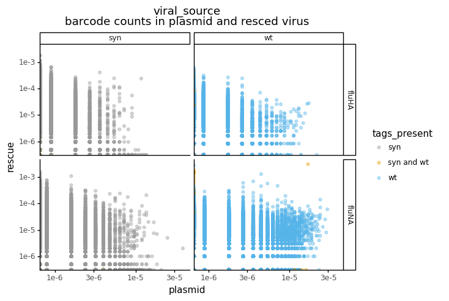

```python
tag_freqs = (viral_bc
             .pivot_table(index=['gene',
                                 'tag',
                                 'barcode',
                                 'tags_present'],
                          columns=['source'],
                          values='freq')
             .fillna(0)
             .reset_index())

display(tag_freqs)

fig = (p9.ggplot(tag_freqs,
                 p9.aes(x='plasmid',
                        y='rescue',
                        color='tags_present')) +
       p9.ggtitle(f'{expt}\n'
                  'barcode counts in plasmid '
                  'and resced virus') +
       p9.geom_point(alpha=0.4) +
       p9.facet_grid('gene~tag') +
       p9.scale_x_log10() +
       p9.scale_y_log10() +
       p9.scale_color_manual(CBPALETTE[0:]))
fig
```

Plot correlation of barcodes in supernatant and in second infection. Color by presence in each (or both) tags.

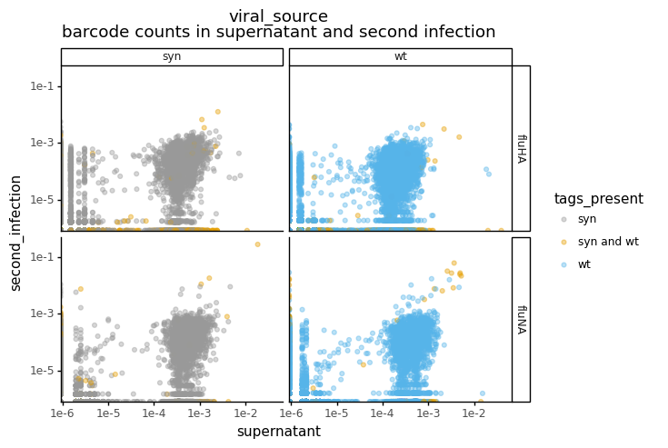

```python
fig = (p9.ggplot(tag_freqs,
                 p9.aes(x='supernatant',
                        y='second_infection',
                        color='tags_present')) +
       p9.ggtitle(f'{expt}\n'
                  'barcode counts in supernatant '
                  'and second infection') +
       p9.geom_point(alpha=0.4) +
       p9.facet_grid('gene~tag') +
       p9.scale_x_log10() +
       p9.scale_y_log10() +
       p9.scale_color_manual(CBPALETTE[0:]))
fig
```